# Project_02A_Attrition Analysis_TH

## McCurr Consultancy .. Attrition Analysis

### Objective ..

To predict if an employee is going to attrite or not

### Step 01 ..

Importing datasets and libraries.

```python
import warnings
warnings.filterwarnings('ignore')
```

```python
# Importing initial libraries
import numpy as np
import pandas as pd
# plotting libraries
import matplotlib.pyplot as plt
# to enable plotting graphs
%matplotlib inline
# imorting Seaborn for statistical plots
import seaborn as sns
```

```python
# Importing datasets
df = pd.read_excel('HR_Employee_Attrition_Dataset.xlsx')
df_Dic = pd.read_excel('HR_Employee_Attrition Data Dictionary.xlsx')
```

#### Checking each dataset for the following:

- Data type
- Statistical summary
- Shape
- Null values
- Incorrect imputations

#### Dataset df = HR_Employee_Attrition_Dataset.xlsx

```python
# Checking Headers for df
df.head()
```

|  | EmployeeNumber | Attrition | Age | BusinessTravel | DailyRate | Department | DistanceFromHome | Education | EducationField | EnvironmentSatisfaction | ... | RelationshipSatisfaction | StandardHours | StockOptionLevel | TotalWorkingYears | TrainingTimesLastYear | WorkLifeBalance | YearsAtCompany | YearsInCurrentRole | YearsSinceLastPromotion | YearsWithCurrManager |
| --- | --- | --- | --- | --- | --- | --- | --- | --- | --- | --- | --- | --- | --- | --- | --- | --- | --- | --- | --- | --- | --- |
| 0 | 1 | Yes | 41 | Travel_Rarely | 1102 | Sales | 1 | 2 | Life Sciences | 2 | ... | 1 | 80 | 0 | 8 | 0 | 1 | 6 | 4 | 0 | 5 |
| 1 | 2 | No | 49 | Travel_Frequently | 279 | Research & Development | 8 | 1 | Life Sciences | 3 | ... | 4 | 80 | 1 | 10 | 3 | 3 | 10 | 7 | 1 | 7 |
| 2 | 3 | Yes | 37 | Travel_Rarely | 1373 | Research & Development | 2 | 2 | Other | 4 | ... | 2 | 80 | 0 | 7 | 3 | 3 | 0 | 0 | 0 | 0 |
| 3 | 4 | No | 33 | Travel_Frequently | 1392 | Research & Development | 3 | 4 | Life Sciences | 4 | ... | 3 | 80 | 0 | 8 | 3 | 3 | 8 | 7 | 3 | 0 |
| 4 | 5 | No | 27 | Travel_Rarely | 591 | Research & Development | 2 | 1 | Medical | 1 | ... | 4 | 80 | 1 | 6 | 3 | 3 | 2 | 2 | 2 | 2 |

5 rows × 34 columns

```python
df.shape
```

```
(2940, 34)
```

```python
df.describe().T
```

|  | count | mean | std | min | 25% | 50% | 75% | max |
| --- | --- | --- | --- | --- | --- | --- | --- | --- |
| EmployeeNumber | 2940.0 | 1470.500000 | 848.849221 | 1.0 | 735.75 | 1470.5 | 2205.25 | 2940.0 |
| Age | 2940.0 | 36.923810 | 9.133819 | 18.0 | 30.00 | 36.0 | 43.00 | 60.0 |
| DailyRate | 2940.0 | 802.485714 | 403.440447 | 102.0 | 465.00 | 802.0 | 1157.00 | 1499.0 |
| DistanceFromHome | 2940.0 | 9.192517 | 8.105485 | 1.0 | 2.00 | 7.0 | 14.00 | 29.0 |
| Education | 2940.0 | 2.912925 | 1.023991 | 1.0 | 2.00 | 3.0 | 4.00 | 5.0 |
| EnvironmentSatisfaction | 2940.0 | 2.721769 | 1.092896 | 1.0 | 2.00 | 3.0 | 4.00 | 4.0 |
| HourlyRate | 2940.0 | 65.891156 | 20.325969 | 30.0 | 48.00 | 66.0 | 84.00 | 100.0 |
| JobInvolvement | 2940.0 | 2.729932 | 0.711440 | 1.0 | 2.00 | 3.0 | 3.00 | 4.0 |
| JobLevel | 2940.0 | 2.063946 | 1.106752 | 1.0 | 1.00 | 2.0 | 3.00 | 5.0 |
| JobSatisfaction | 2940.0 | 2.728571 | 1.102658 | 1.0 | 2.00 | 3.0 | 4.00 | 4.0 |
| MonthlyIncome | 2940.0 | 6502.931293 | 4707.155770 | 1009.0 | 2911.00 | 4919.0 | 8380.00 | 19999.0 |
| MonthlyRate | 2940.0 | 14313.103401 | 7116.575021 | 2094.0 | 8045.00 | 14235.5 | 20462.00 | 26999.0 |
| NumCompaniesWorked | 2940.0 | 2.693197 | 2.497584 | 0.0 | 1.00 | 2.0 | 4.00 | 9.0 |
| PercentSalaryHike | 2940.0 | 15.209524 | 3.659315 | 11.0 | 12.00 | 14.0 | 18.00 | 25.0 |
| PerformanceRating | 2940.0 | 3.153741 | 0.360762 | 3.0 | 3.00 | 3.0 | 3.00 | 4.0 |
| RelationshipSatisfaction | 2940.0 | 2.712245 | 1.081025 | 1.0 | 2.00 | 3.0 | 4.00 | 4.0 |
| StandardHours | 2940.0 | 80.000000 | 0.000000 | 80.0 | 80.00 | 80.0 | 80.00 | 80.0 |
| StockOptionLevel | 2940.0 | 0.793878 | 0.851932 | 0.0 | 0.00 | 1.0 | 1.00 | 3.0 |
| TotalWorkingYears | 2940.0 | 11.279592 | 7.779458 | 0.0 | 6.00 | 10.0 | 15.00 | 40.0 |
| TrainingTimesLastYear | 2940.0 | 2.799320 | 1.289051 | 0.0 | 2.00 | 3.0 | 3.00 | 6.0 |
| WorkLifeBalance | 2940.0 | 2.761224 | 0.706356 | 1.0 | 2.00 | 3.0 | 3.00 | 4.0 |
| YearsAtCompany | 2940.0 | 7.008163 | 6.125483 | 0.0 | 3.00 | 5.0 | 9.00 | 40.0 |
| YearsInCurrentRole | 2940.0 | 4.229252 | 3.622521 | 0.0 | 2.00 | 3.0 | 7.00 | 18.0 |
| YearsSinceLastPromotion | 2940.0 | 2.187755 | 3.221882 | 0.0 | 0.00 | 1.0 | 3.00 | 15.0 |
| YearsWithCurrManager | 2940.0 | 4.123129 | 3.567529 | 0.0 | 2.00 | 3.0 | 7.00 | 17.0 |

```python
#checking for missing values - dataset has no missing values
df.isnull().sum()
```

```
EmployeeNumber              0
Attrition                   0
Age                         0
BusinessTravel              0
DailyRate                   0
Department                  0
DistanceFromHome            0
Education                   0
EducationField              0
EnvironmentSatisfaction     0
Gender                      0
HourlyRate                  0
JobInvolvement              0
JobLevel                    0
JobRole                     0
JobSatisfaction             0
MaritalStatus               0
MonthlyIncome               0
MonthlyRate                 0
NumCompaniesWorked          0
Over18                      0
OverTime                    0
PercentSalaryHike           0
PerformanceRating           0
RelationshipSatisfaction    0
StandardHours               0
StockOptionLevel            0
TotalWorkingYears           0
TrainingTimesLastYear       0
WorkLifeBalance             0
YearsAtCompany              0
YearsInCurrentRole          0
YearsSinceLastPromotion     0
YearsWithCurrManager        0
dtype: int64
```

```python
df.info()
# Having a problem with x.head() since it doesn't show full column heads, so I have to verify using info()
# Checking columns and nature of content
```

```
<class 'pandas.core.frame.DataFrame'>
RangeIndex: 2940 entries, 0 to 2939
Data columns (total 34 columns):
 #   Column                    Non-Null Count  Dtype
---  ------                    --------------  -----
 0   EmployeeNumber            2940 non-null   int64
 1   Attrition                 2940 non-null   object
 2   Age                       2940 non-null   int64
 3   BusinessTravel            2940 non-null   object
 4   DailyRate                 2940 non-null   int64
 5   Department                2940 non-null   object
 6   DistanceFromHome          2940 non-null   int64
 7   Education                 2940 non-null   int64
 8   EducationField            2940 non-null   object
 9   EnvironmentSatisfaction   2940 non-null   int64
```

[output cut: 26 more lines]

- df has 25 columns (int64)
- df has 9 coumns (object)
- Checking the content of objects in the 9 columns

```python
df.columns.to_series().groupby(df.dtypes).groups
```

```
{dtype('int64'): Index(['EmployeeNumber', 'Age', 'DailyRate', 'DistanceFromHome', 'Education',
        'EnvironmentSatisfaction', 'HourlyRate', 'JobInvolvement', 'JobLevel',
        'JobSatisfaction', 'MonthlyIncome', 'MonthlyRate', 'NumCompaniesWorked',
        'PercentSalaryHike', 'PerformanceRating', 'RelationshipSatisfaction',
        'StandardHours', 'StockOptionLevel', 'TotalWorkingYears',
        'TrainingTimesLastYear', 'WorkLifeBalance', 'YearsAtCompany',
        'YearsInCurrentRole', 'YearsSinceLastPromotion',
        'YearsWithCurrManager'],
       dtype='object'),
 dtype('O'): Index(['Attrition', 'BusinessTravel', 'Department', 'EducationField', 'Gender',
        'JobRole', 'MaritalStatus', 'Over18', 'OverTime'],
       dtype='object')}
```

- Understanding the details of Columns containing Objects
- Range or diversity in each column, having 2 variables or more and thier category

```python
print(df['Attrition'].value_counts())
# Target Attribute
```

[output not shown]

```python
print(df['BusinessTravel'].value_counts())
```

```
Travel_Rarely        2086
Travel_Frequently     554
Non-Travel            300
Name: BusinessTravel, dtype: int64
```

```python
print(df['Department'].value_counts())
```

```
Research & Development    1922
Sales                      892
Human Resources            126
Name: Department, dtype: int64
```

```python
print(df['EducationField'].value_counts())
```

```
Life Sciences       1212
Medical              928
Marketing            318
Technical Degree     264
Other                164
Human Resources       54
Name: EducationField, dtype: int64
```

```python
print(df['Gender'].value_counts())
```

```
Male      1764
Female    1176
Name: Gender, dtype: int64
```

```python
print(df['JobRole'].value_counts())
```

```
Sales Executive              652
Research Scientist           584
Laboratory Technician        518
Manufacturing Director       290
Healthcare Representative    262
Manager                      204
Sales Representative         166
Research Director            160
Human Resources              104
Name: JobRole, dtype: int64
```

```python
print(df['MaritalStatus'].value_counts())
```

```
Married     1346
Single       940
Divorced     654
Name: MaritalStatus, dtype: int64
```

```python
print(df['Over18'].value_counts())
```

```
Y    2940
Name: Over18, dtype: int64
```

```python
print(df['OverTime'].value_counts())
```

```
No     2108
Yes     832
Name: OverTime, dtype: int64
```

#### Dataset df_Dic = HR_Employee_Attrition Data Dictionary.xlsx

```python
# Checking Headers fpr df_Dic
df_Dic.head()
```

|  | Unnamed: 0 | Unnamed: 1 | Unnamed: 2 | Unnamed: 3 |
| --- | --- | --- | --- | --- |
| 0 | NaN | NaN | Data Dictionary | NaN |
| 1 | NaN | NaN | NaN | NaN |
| 2 | NaN | NaN | Feature | Explanation |
| 3 | NaN | NaN | Education | 1 'Below College' |
| 4 | NaN | NaN | NaN | 2 'College' |

```python
df_Dic.shape
```

```
(38, 4)
```

```python
df_Dic.info()
```

```
<class 'pandas.core.frame.DataFrame'>
RangeIndex: 38 entries, 0 to 37
Data columns (total 4 columns):
 #   Column      Non-Null Count  Dtype
---  ------      --------------  -----
 0   Unnamed: 0  0 non-null      float64
 1   Unnamed: 1  0 non-null      float64
 2   Unnamed: 2  9 non-null      object
 3   Unnamed: 3  30 non-null     object
dtypes: float64(2), object(2)
memory usage: 1.3+ KB
```

```python
uniqueValues = df_Dic.nunique()
print('Count of unique values in each column :')
print(uniqueValues)
```

```
Count of unique values in each column :
Unnamed: 0     0
Unnamed: 1     0
Unnamed: 2     9
Unnamed: 3    16
dtype: int64
```

- Dataset df_Dic contains empty columns and rows with no data
- Removing empty columns and rows

```python
# df_Dic01 has no empty columns
df_Dic01 = df_Dic.dropna(axis=1, how='all')
df_Dic01
```

|  | Unnamed: 2 | Unnamed: 3 |
| --- | --- | --- |
| 0 | Data Dictionary | NaN |
| 1 | NaN | NaN |
| 2 | Feature | Explanation |
| 3 | Education | 1 'Below College' |
| 4 | NaN | 2 'College' |
| 5 | NaN | 3 'Bachelor' |
| 6 | NaN | 4 'Master' |
| 7 | NaN | 5 'Doctor' |
| 8 | NaN | NaN |
| 9 | EnvironmentSatisfaction | 1 'Low' |
| 10 | NaN | 2 'Medium' |
| 11 | NaN | 3 'High' |
| 12 | NaN | 4 'Very High' |
| 13 | NaN | NaN |
| 14 | JobInvolvement | 1 'Low' |
| 15 | NaN | 2 'Medium' |
| 16 | NaN | 3 'High' |
| 17 | NaN | 4 'Very High' |
| 18 | NaN | NaN |
| 19 | JobSatisfaction | 1 'Low' |
| 20 | NaN | 2 'Medium' |
| 21 | NaN | 3 'High' |
| 22 | NaN | 4 'Very High' |
| 23 | NaN | NaN |
| 24 | PerformanceRating | 1 'Low' |
| 25 | NaN | 2 'Good' |
| 26 | NaN | 3 'Excellent' |
| 27 | NaN | 4 'Outstanding' |
| 28 | NaN | NaN |
| 29 | RelationshipSatisfaction | 1 'Low' |
| 30 | NaN | 2 'Medium' |
| 31 | NaN | 3 'High' |
| 32 | NaN | 4 'Very High' |
| 33 | NaN | NaN |
| 34 | WorkLifeBalance | 1 'Bad' |
| 35 | NaN | 2 'Good' |
| 36 | NaN | 3 'Better' |
| 37 | NaN | 4 'Best' |

```python
# df_Dic02 has no empty rows
df_Dic02 = df_Dic01.dropna(how='all')
df_Dic02
```

|  | Unnamed: 2 | Unnamed: 3 |
| --- | --- | --- |
| 0 | Data Dictionary | NaN |
| 2 | Feature | Explanation |
| 3 | Education | 1 'Below College' |
| 4 | NaN | 2 'College' |
| 5 | NaN | 3 'Bachelor' |
| 6 | NaN | 4 'Master' |
| 7 | NaN | 5 'Doctor' |
| 9 | EnvironmentSatisfaction | 1 'Low' |
| 10 | NaN | 2 'Medium' |
| 11 | NaN | 3 'High' |
| 12 | NaN | 4 'Very High' |
| 14 | JobInvolvement | 1 'Low' |
| 15 | NaN | 2 'Medium' |
| 16 | NaN | 3 'High' |
| 17 | NaN | 4 'Very High' |
| 19 | JobSatisfaction | 1 'Low' |
| 20 | NaN | 2 'Medium' |
| 21 | NaN | 3 'High' |
| 22 | NaN | 4 'Very High' |
| 24 | PerformanceRating | 1 'Low' |
| 25 | NaN | 2 'Good' |
| 26 | NaN | 3 'Excellent' |
| 27 | NaN | 4 'Outstanding' |
| 29 | RelationshipSatisfaction | 1 'Low' |
| 30 | NaN | 2 'Medium' |
| 31 | NaN | 3 'High' |
| 32 | NaN | 4 'Very High' |
| 34 | WorkLifeBalance | 1 'Bad' |
| 35 | NaN | 2 'Good' |
| 36 | NaN | 3 'Better' |
| 37 | NaN | 4 'Best' |

```python
# df_Dic02 after removing all empty columns and rows
df_Dic02.shape
```

```
(31, 2)
```

Dataset df_Dic02 has the dictionary explaining the features used in the main 'df file' and the corresponding range of levels and/or values used therein

```python
# Features used in df
df_Dic02['Unnamed: 2'].unique()
```

```
array(['Data Dictionary', 'Feature', 'Education', nan,
       'EnvironmentSatisfaction', 'JobInvolvement', 'JobSatisfaction',
       'PerformanceRating', 'RelationshipSatisfaction', 'WorkLifeBalance'],
      dtype=object)
```

```python
df_Dic02['Unnamed: 3'].unique()
```

```
array([nan, 'Explanation', "1 'Below College'", "2 'College'",
       "3 'Bachelor'", "4 'Master'", "5 'Doctor'", "1 'Low'",
       "2 'Medium'", "3 'High'", "4 'Very High'", "2 'Good'",
       "3 'Excellent'", "4 'Outstanding'", "1 'Bad'", "3 'Better'",
       "4 'Best'"], dtype=object)
```

### Step 02 ..

#### EDA for the datasts will include the following ..

- Univariate analysis
- Bi-variate analysis
- Preparing data model

#### General Overview ..

```python
print(df['Over18'].value_counts())
# Column has the same value for all rows
```

```
Y    2940
Name: Over18, dtype: int64
```

```python
print(df['StandardHours'].value_counts())
# Column has the same value (80) for all rows
```

```
80    2940
Name: StandardHours, dtype: int64
```

```python
df01 = df.drop(['EmployeeNumber','DailyRate','HourlyRate', 'Over18', 'StandardHours'],axis=1,inplace=False)
df01.shape
```

```
(2940, 29)
```

#### Univariate Analysis ..

This analysis includes distribution plots for the numerical attributes. The analysis will be performed on Dataset df01 i.e. the set after initially dropping the columns that are not required for this analysis

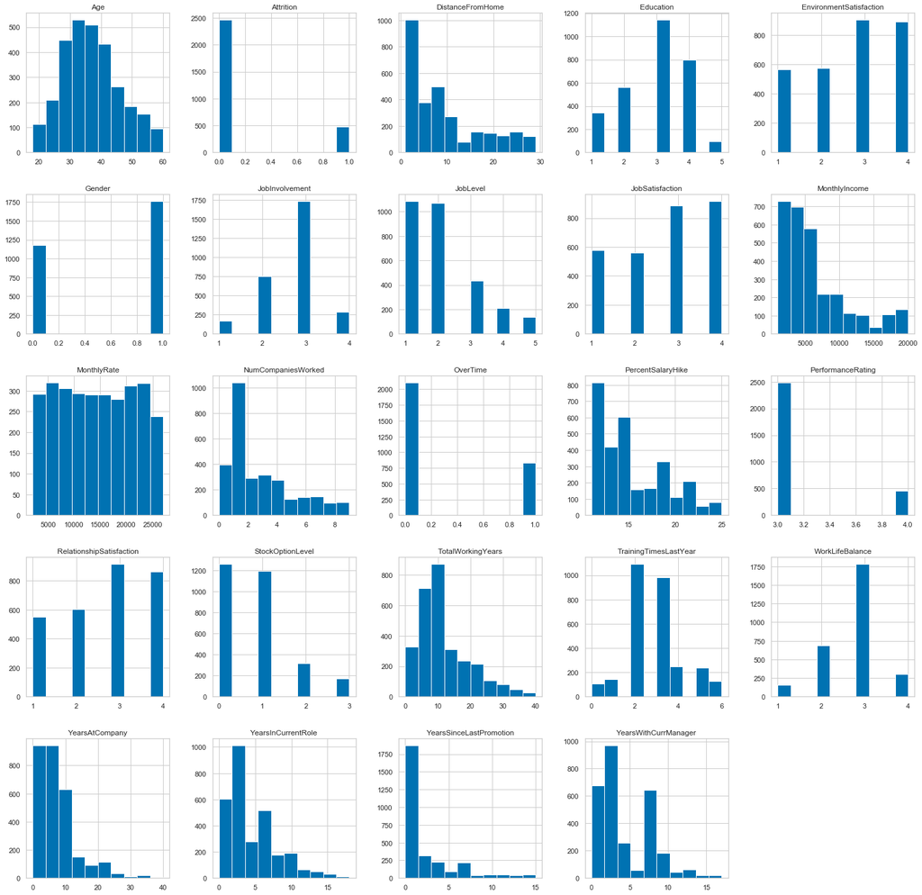

```python
df01.hist(figsize=(25,25))
plt.show()
```

#### Observations based on the above histograms for the numerical attributes ..

- Age distribution bulk staff is between 25 and 45 years old. Age is slightly skewed.
- Many histograms are skewed 'right' such as 'Distance From Home', 'Monthly Income', 'Percent Salary Hike', 'Years Current Role, 'Years at Company', 'Total Working Years', etc.

#### Bivariate Analysis ..

This is part of the EDA is mainly about feature distribution by target attribute 'Attrition'

- Dataset df01 will be used for the purpose of this comparisons as will be illustrated hereunder
- An Employee who left the Company is termed 'Attrit', plural 'Attrits'
- Where the term 'Attrit' is utilized, it represents the observations of 'Yes' under 'Attrition' or Employees who have already left company
- On the other hand, existing company employees will be termed 'Active' and will represent the observations of 'No' under 'Attrition'

#### General Overview of Features ..

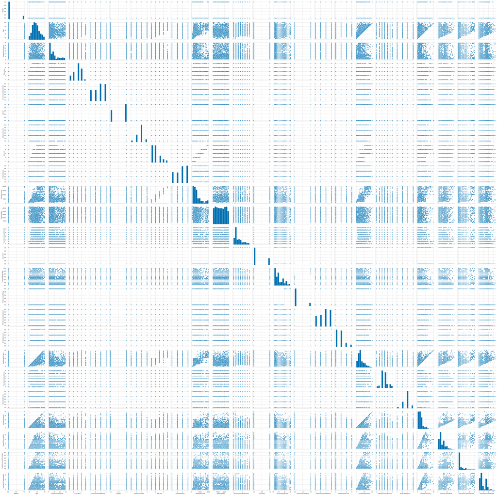

```python
sns.pairplot(df01)
plt.show()
# General overview of Attributes
```

#### Detailed Analysis of Features ..

The detailed analysis hereunder is covering a sample of the ket attributes affecting the Attrition

#### Target Attribute: Attrition

```python
print(df['Attrition'].value_counts())
# Target Attribute
print()
print("Number of Active Employees is {:} and Attrits is: {:}".format(
    df01[df01['Attrition'] == 'No'].shape[0],
    df01[df01['Attrition'] == 'Yes'].shape[0]))
```

```
No     2466
Yes     474
Name: Attrition, dtype: int64

Number of Active Employees is 0 and Attrits is: 0
```

```python
print("Percentage of Active Employees is: {:.1f}% and Attrits is: {:.1f}%".format(
    df01[df01['Attrition'] == 'No'].shape[0] / df01.shape[0]*100,
    df01[df01['Attrition'] == 'Yes'].shape[0] / df01.shape[0]*100))
```

```
Percentage of Active Employees is: 0.0% and Attrits is: 0.0%
```

```
0    83.877551
1    16.122449
Name: Attrition, dtype: float64
```

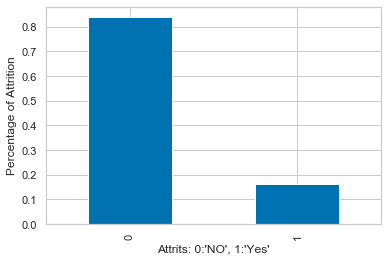

```python
print(df01['Attrition'].value_counts(normalize=True)*100)
print()
df01['Attrition'].value_counts(normalize=True).plot(kind='bar')
plt.xlabel("Attrits: 0:'NO', 1:'Yes'")
plt.ylabel("Percentage of Attrition")
plt.show()
```

#### Attribute: Gender

```python
pd.crosstab(df01['Attrition'], df['Gender'])
# Total number of Attrits 'Yes' in relation to 'Gender' attribute
```

| Gender Attrition | Female | Male |
| --- | --- | --- |
| 0 | 1002 | 1464 |
| 1 | 174 | 300 |

```python
pd.crosstab(df01['Attrition'], df01['Gender'],normalize='index')
# Percentage of Attrits 'Yes' in relation to 'Gender' attribute
```

| Gender Attrition | 0 | 1 |
| --- | --- | --- |
| 0 | 0.406326 | 0.593674 |
| 1 | 0.367089 | 0.632911 |

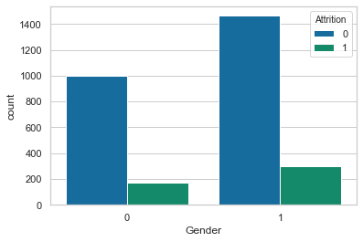

```python
Gender_Attrition = sns.countplot(x="Gender", hue="Attrition", data=df01)
sns.set_style("whitegrid")
```

#### Attribute: MaritalStatus

```python
pd.crosstab(df01['Attrition'], df['MaritalStatus'])
# Total number of Attrits 'Yes' in relation to 'MaritalStatus' attribute
```

| MaritalStatus Attrition | Divorced | Married | Single |
| --- | --- | --- | --- |
| No | 588 | 1178 | 700 |
| Yes | 66 | 168 | 240 |

```python
pd.crosstab(df01['Attrition'], df['MaritalStatus'], normalize = 'index')
# Percentage of Attrits 'Yes' in relation to 'MaritalStatus' attribute
```

| MaritalStatus Attrition | Divorced | Married | Single |
| --- | --- | --- | --- |
| No | 0.238443 | 0.477697 | 0.283861 |
| Yes | 0.139241 | 0.354430 | 0.506329 |

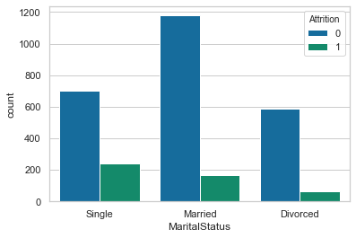

```python
MaritalStatus_Attrition = sns.countplot(x="MaritalStatus", hue="Attrition", data=df01)
sns.set_style("whitegrid")
```

#### Attribute: BusinessTravel

```python
pd.crosstab(df01['Attrition'], df01['BusinessTravel'])
# Total number of Attrits 'Yes' in relation to 'BusinessTravle' attribute
```

| BusinessTravel Attrition | Non-Travel | Travel_Frequently | Travel_Rarely |
| --- | --- | --- | --- |
| 0 | 276 | 416 | 1774 |
| 1 | 24 | 138 | 312 |

```python
pd.crosstab(df01['Attrition'], df01['BusinessTravel'],normalize='index')
# Percentage of Attrits 'Yes' in relation to 'BusinessTravle' attribute
```

[output not shown]

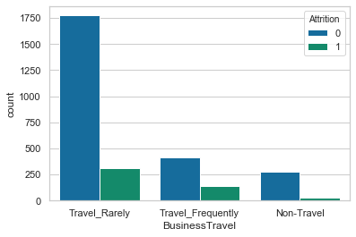

```python
BuisineeTravel_Attrition = sns.countplot(x="BusinessTravel", hue="Attrition", data=df01)
sns.set_style("whitegrid")
```

#### Attribute: DistanceFromHome

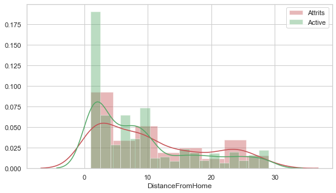

```python
plt.figure(figsize=(9,5))
sns.distplot(df[df['Attrition']=='Yes']['DistanceFromHome'],color='r',label='Attrits')
sns.distplot(df[df['Attrition']=='No']['DistanceFromHome'],color='g',label='Active')
plt.legend()
plt.show()
```

#### Attribute: MonthlyIncome

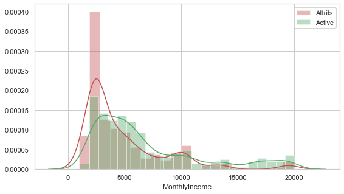

```python
plt.figure(figsize=(9,5))
sns.distplot(df[df['Attrition']=='Yes']['MonthlyIncome'],color='r',label='Attrits')
sns.distplot(df[df['Attrition']=='No']['MonthlyIncome'],color='g',label='Active')
plt.legend()
plt.show()
```

#### Attribute: OverTime

```python
pd.crosstab(df01['Attrition'], df['OverTime'])
# Total number of Attrits 'Yes' in relation to 'OverTime' attribute
```

| OverTime Attrition | No | Yes |
| --- | --- | --- |
| 0 | 1888 | 578 |
| 1 | 220 | 254 |

```python
pd.crosstab(df01['Attrition'], df01['OverTime'],normalize='index')
# Percentage of Attrits 'Yes' in relation to 'OverTime' attribute
```

| OverTime Attrition | 0 | 1 |
| --- | --- | --- |
| 0 | 0.765612 | 0.234388 |
| 1 | 0.464135 | 0.535865 |

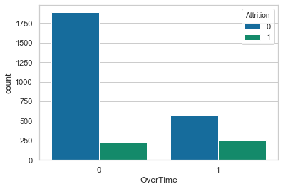

```python
OverTime_Attrition = sns.countplot(x="OverTime", hue="Attrition", data=df01)
sns.set_style("whitegrid")
```

#### Attribute: Education

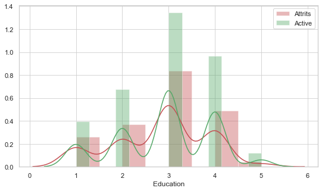

```python
plt.figure(figsize=(9,5))
sns.distplot(df[df['Attrition']=='Yes']['Education'],color='r',label='Attrits')
sns.distplot(df[df['Attrition']=='No']['Education'],color='g',label='Active')
plt.grid(True, alpha=0.8)
plt.legend()
plt.show()
```

#### Attribute: Age

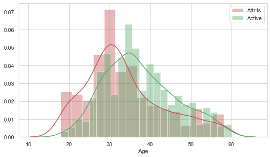

```python
plt.figure(figsize=(9,5))
sns.distplot(df[df['Attrition']=='Yes']['Age'],color='r',label='Attrits')
sns.distplot(df[df['Attrition']=='No']['Age'],color='g',label='Active')
plt.grid(True, alpha=0.8)
plt.legend()
plt.show()
```

#### Correlation

```python
# Find correlations with the target and sort
df01_trans = df.copy()

df01_trans['Target'] = df01_trans['Attrition'].apply(
    lambda x: 0 if x == 'No' else 1)
df01_trans = df01_trans.drop(
    ['Attrition',], axis=1)

correlations = df01_trans.corr()['Target'].sort_values()
print('Most Positive Correlations: \n', correlations.tail(10))
print('\nMost Negative Correlations: \n', correlations.head(10))
```

```
Most Positive Correlations:
 Education            -0.031373
PercentSalaryHike    -0.013478
HourlyRate           -0.006846
EmployeeNumber       -0.005184
PerformanceRating     0.002889
MonthlyRate           0.015170
NumCompaniesWorked    0.043494
DistanceFromHome      0.077924
Target                1.000000
StandardHours              NaN
Name: Target, dtype: float64

Most Negative Correlations:
 TotalWorkingYears      -0.171063
JobLevel               -0.169105
YearsInCurrentRole     -0.160545
MonthlyIncome          -0.159840
Age                    -0.159205
YearsWithCurrManager   -0.156199
StockOptionLevel       -0.137145
YearsAtCompany         -0.134392
JobInvolvement         -0.130016
JobSatisfaction        -0.103481
Name: Target, dtype: float64
```

#### Correlation Heat Map

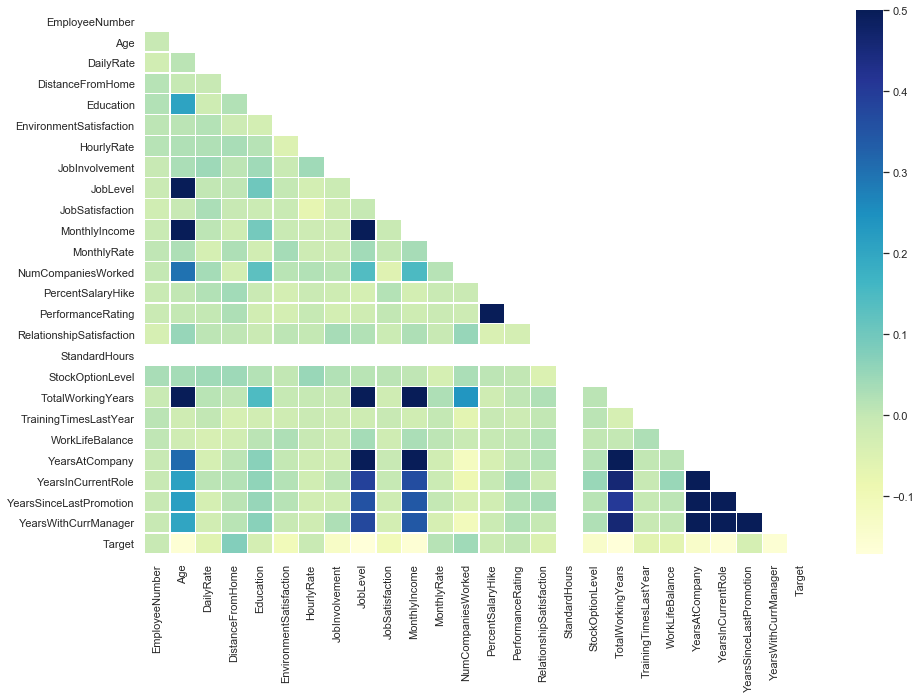

```python
corr = df01_trans.corr()
mask = np.zeros_like(corr)
mask[np.triu_indices_from(mask)] = True
# Heatmap
plt.figure(figsize=(15, 10))
sns.heatmap(corr,
            vmax=.5,
            mask=mask,
            # annot=True, fmt='.2f',
            linewidths=.2, cmap="YlGnBu")
```

### Step 03 ..

#### Preparing and getting the data model ready

```python
x = df01.loc[:, df01.columns != 'Attrition']  # independent variables

y = df01.loc[:, df01.columns == 'Attrition']  # Target variable
```

```python
# import LabelEncoder
from sklearn.preprocessing import LabelEncoder
# Instatniate LabelEncoder
le = LabelEncoder()

df01["Attrition"] = le.fit_transform(df["Attrition"])
# Inspecting encoded df
df01.head()
```

|  | Attrition | Age | BusinessTravel | Department | DistanceFromHome | Education | EducationField | EnvironmentSatisfaction | Gender | JobInvolvement | ... | PerformanceRating | RelationshipSatisfaction | StockOptionLevel | TotalWorkingYears | TrainingTimesLastYear | WorkLifeBalance | YearsAtCompany | YearsInCurrentRole | YearsSinceLastPromotion | YearsWithCurrManager |
| --- | --- | --- | --- | --- | --- | --- | --- | --- | --- | --- | --- | --- | --- | --- | --- | --- | --- | --- | --- | --- | --- |
| 0 | 1 | 41 | Travel_Rarely | Sales | 1 | 2 | Life Sciences | 2 | 0 | 3 | ... | 3 | 1 | 0 | 8 | 0 | 1 | 6 | 4 | 0 | 5 |
| 1 | 0 | 49 | Travel_Frequently | Research & Development | 8 | 1 | Life Sciences | 3 | 1 | 2 | ... | 4 | 4 | 1 | 10 | 3 | 3 | 10 | 7 | 1 | 7 |
| 2 | 1 | 37 | Travel_Rarely | Research & Development | 2 | 2 | Other | 4 | 1 | 2 | ... | 3 | 2 | 0 | 7 | 3 | 3 | 0 | 0 | 0 | 0 |
| 3 | 0 | 33 | Travel_Frequently | Research & Development | 3 | 4 | Life Sciences | 4 | 0 | 3 | ... | 3 | 3 | 0 | 8 | 3 | 3 | 8 | 7 | 3 | 0 |
| 4 | 0 | 27 | Travel_Rarely | Research & Development | 2 | 1 | Medical | 1 | 1 | 3 | ... | 3 | 4 | 1 | 6 | 3 | 3 | 2 | 2 | 2 | 2 |

5 rows × 29 columns

```python
# To transform values from Yes/No to 1/0
y = le.fit_transform(y)
print(y)
```

```
[1 0 1 ... 0 0 0]
```

```python
x = pd.get_dummies(x,drop_first=True)
```

```python
x.head()
```

|  | Age | DistanceFromHome | Education | EnvironmentSatisfaction | JobInvolvement | JobLevel | JobSatisfaction | MonthlyIncome | MonthlyRate | NumCompaniesWorked | ... | JobRole_Laboratory Technician | JobRole_Manager | JobRole_Manufacturing Director | JobRole_Research Director | JobRole_Research Scientist | JobRole_Sales Executive | JobRole_Sales Representative | MaritalStatus_Married | MaritalStatus_Single | OverTime_Yes |
| --- | --- | --- | --- | --- | --- | --- | --- | --- | --- | --- | --- | --- | --- | --- | --- | --- | --- | --- | --- | --- | --- |
| 0 | 41 | 1 | 2 | 2 | 3 | 2 | 4 | 5993 | 19479 | 8 | ... | 0 | 0 | 0 | 0 | 0 | 1 | 0 | 0 | 1 | 1 |
| 1 | 49 | 8 | 1 | 3 | 2 | 2 | 2 | 5130 | 24907 | 1 | ... | 0 | 0 | 0 | 0 | 1 | 0 | 0 | 1 | 0 | 0 |
| 2 | 37 | 2 | 2 | 4 | 2 | 1 | 3 | 2090 | 2396 | 6 | ... | 1 | 0 | 0 | 0 | 0 | 0 | 0 | 0 | 1 | 1 |
| 3 | 33 | 3 | 4 | 4 | 3 | 1 | 3 | 2909 | 23159 | 1 | ... | 0 | 0 | 0 | 0 | 1 | 0 | 0 | 1 | 0 | 1 |
| 4 | 27 | 2 | 1 | 1 | 3 | 1 | 2 | 3468 | 16632 | 9 | ... | 1 | 0 | 0 | 0 | 0 | 0 | 0 | 1 | 0 | 0 |

5 rows × 42 columns

```python
x.shape
# Verifying the additional number of columns
# Columns increased from 29 to 42 due to labeling and OHC
```

```
(2940, 42)
```

#### Split the dataset into (1) training and (2) test dataset in the ratio of 70:30 respectively

```python
from sklearn.model_selection import train_test_split
xtrain,xtest,ytrain,ytest = train_test_split(x,y,test_size=0.3,random_state=7)

# two variables taken for split therefore output will generate 4 variables:
# test and train output for x
# test and train output for y
```

```python
xtrain.head()
```

|  | Age | DistanceFromHome | Education | EnvironmentSatisfaction | Gender | JobInvolvement | JobLevel | JobSatisfaction | MonthlyIncome | MonthlyRate | ... | JobRole_Human Resources | JobRole_Laboratory Technician | JobRole_Manager | JobRole_Manufacturing Director | JobRole_Research Director | JobRole_Research Scientist | JobRole_Sales Executive | JobRole_Sales Representative | MaritalStatus_Married | MaritalStatus_Single |
| --- | --- | --- | --- | --- | --- | --- | --- | --- | --- | --- | --- | --- | --- | --- | --- | --- | --- | --- | --- | --- | --- |
| 1906 | 33 | 10 | 1 | 1 | 1 | 1 | 1 | 4 | 3408 | 6705 | ... | 0 | 1 | 0 | 0 | 0 | 0 | 0 | 0 | 0 | 0 |
| 2820 | 27 | 2 | 2 | 1 | 0 | 4 | 2 | 3 | 6500 | 26997 | ... | 0 | 0 | 0 | 0 | 0 | 0 | 1 | 0 | 0 | 1 |
| 2825 | 36 | 17 | 2 | 3 | 1 | 2 | 2 | 2 | 5507 | 16822 | ... | 0 | 0 | 0 | 0 | 0 | 0 | 1 | 0 | 1 | 0 |
| 382 | 26 | 3 | 1 | 3 | 1 | 3 | 1 | 1 | 3102 | 6582 | ... | 0 | 0 | 0 | 0 | 0 | 1 | 0 | 0 | 0 | 1 |
| 2911 | 56 | 1 | 4 | 3 | 1 | 3 | 2 | 3 | 6306 | 26236 | ... | 0 | 0 | 0 | 0 | 0 | 0 | 0 | 0 | 0 | 0 |

5 rows × 42 columns

```python
# Confirming the split of the train dataset
xtrain.shape
```

```
(2058, 42)
```

```python
xtest.head()
```

|  | Age | DistanceFromHome | Education | EnvironmentSatisfaction | Gender | JobInvolvement | JobLevel | JobSatisfaction | MonthlyIncome | MonthlyRate | ... | JobRole_Human Resources | JobRole_Laboratory Technician | JobRole_Manager | JobRole_Manufacturing Director | JobRole_Research Director | JobRole_Research Scientist | JobRole_Sales Executive | JobRole_Sales Representative | MaritalStatus_Married | MaritalStatus_Single |
| --- | --- | --- | --- | --- | --- | --- | --- | --- | --- | --- | --- | --- | --- | --- | --- | --- | --- | --- | --- | --- | --- |
| 1522 | 44 | 1 | 5 | 2 | 0 | 3 | 2 | 1 | 5454 | 4009 | ... | 0 | 0 | 0 | 0 | 0 | 0 | 1 | 0 | 0 | 0 |
| 1054 | 49 | 7 | 4 | 3 | 1 | 3 | 3 | 2 | 10466 | 20948 | ... | 0 | 0 | 0 | 0 | 0 | 0 | 0 | 0 | 0 | 0 |
| 2272 | 33 | 7 | 3 | 4 | 0 | 3 | 2 | 2 | 4302 | 13401 | ... | 0 | 0 | 0 | 0 | 0 | 0 | 1 | 0 | 1 | 0 |
| 2218 | 26 | 29 | 2 | 2 | 1 | 1 | 2 | 1 | 4969 | 21813 | ... | 0 | 0 | 0 | 0 | 0 | 0 | 1 | 0 | 0 | 1 |
| 2094 | 53 | 7 | 2 | 1 | 0 | 2 | 3 | 4 | 10934 | 20715 | ... | 0 | 0 | 0 | 0 | 0 | 0 | 1 | 0 | 1 | 0 |

5 rows × 42 columns

```python
# Confirming the split of the test dataset
xtest.shape
```

```
(882, 42)
```

### Step 04 ..

#### Logistic Regeression .. Base model and predictions

```python
from sklearn.linear_model import LogisticRegression   # importing logistic regression from scikit learn

model = LogisticRegression(random_state=7)
model.fit(xtrain, ytrain) #training of the model
```

```
LogisticRegression(C=1.0, class_weight=None, dual=False, fit_intercept=True,
                   intercept_scaling=1, l1_ratio=None, max_iter=100,
                   multi_class='auto', n_jobs=None, penalty='l2',
                   random_state=7, solver='lbfgs', tol=0.0001, verbose=0,
                   warm_start=False)
```

```python
y_predict = model.predict(xtest)
# The model is predicting y values based on test dataset given to the model
```

```python
print("Trainig accuracy",model.score(xtrain,ytrain))
# this will give training accuracy as training data has been used
print()
print("Testing accuracy",model.score(xtest, ytest))
# this will give testing accuracy as testing data has been used
```

```
Trainig accuracy 0.8488824101068999

Testing accuracy 0.828798185941043
```

```python
# importing necessary perforance metrics to evaluate the model
from sklearn.metrics import confusion_matrix, recall_score, precision_score, f1_score, roc_auc_score
```

```python
confusion_matrix(ytest, y_predict)
```

```
array([[722,   4],
       [147,   9]], dtype=int64)
```

```python
# Plotting the confusion matrix
def draw_cm(actual, predicted):
    cm = confusion_matrix(actual, predicted)
    sns.heatmap(cm, annot=True,  fmt='.2f', xticklabels = [0,1] , yticklabels = [0,1] )
    plt.ylabel('Observed')
    plt.xlabel('Predicted')
    plt.show()
```

[figure not shown]

```python
draw_cm(ytest,y_predict)
```

```python
recall_score(ytest,y_predict)
```

```
0.057692307692307696
```

```python
precision_score(ytest,y_predict,)
```

[output not shown]

```python
f1_score(ytest,y_predict,)
```

[output not shown]

```python
roc_auc_score(ytest,y_predict)
```

[output not shown]

### Step 05 ..

#### Improving Model Performance

- Imporving the model performance will be through checking the paramaters of the Logistic Regression.
- Performance of model will be checked through different values for 'solvers' and other parameters including penalty, class weight, etc.
- Throgh comparing the resulting corresponding scores for train and test, the final model will be tued and updated.

```python
model.get_params()
```

[output not shown]

```python
# Running a loop to check different values for 'solver'
# Obtaining the resulting scores for comparison

train_score=[]
test_score=[]
solver = ['newton-cg','lbfgs','liblinear','sag','saga']
for i in solver:
    model = LogisticRegression(random_state=7,penalty='l2', solver=i)  # changing values of solver
    model.fit(xtrain, ytrain)
    y_predict = model.predict(xtest)
    train_score.append(round(model.score(xtrain,ytrain),3))
    test_score.append(round(model.score(xtest, ytest),3))

print(solver)
print()
print(train_score)
print()
print(test_score)
```

```
['newton-cg', 'lbfgs', 'liblinear', 'sag', 'saga']

[0.904, 0.849, 0.889, 0.845, 0.845]

[0.872, 0.829, 0.849, 0.823, 0.823]
```

```python
train_score=[]
test_score=[]
solver = ['liblinear','saga']
for i in solver:
    model = LogisticRegression(random_state=7,penalty='l1', solver=i)  # changed value of penaly to 'l1'
    model.fit(xtrain, ytrain)
    y_predict = model.predict(xtest)
    train_score.append(round(model.score(xtrain,ytrain),3))
    test_score.append(round(model.score(xtest, ytest),3))

print(solver)
print()
print(train_score)
print()
print(test_score)
```

```
['liblinear', 'saga']

[0.904, 0.845]

[0.871, 0.823]
```

```python
model = LogisticRegression(random_state=7,penalty='l2',solver='newton-cg',class_weight='balanced') # changing class weight to balanced

model.fit(xtrain, ytrain)

y_predict = model.predict(xtest)

print("Trainig accuracy",model.score(xtrain,ytrain))
print()
print("Testing accuracy",model.score(xtest, ytest))
```

```
Trainig accuracy 0.7959183673469388

Testing accuracy 0.7687074829931972
```

- Resulting accuracy scores for train and test are not better than the original model
- Other parameters 'class weight' will be checked seeking better scores

```python
# Running a loop to check different values for class weight 'C'

train_score=[]
test_score=[]
C = [0.01,0.1,0.25,0.5,0.75,1]
for i in C:
    model = LogisticRegression(random_state=7,penalty='l1',solver='liblinear', C=i)  # changing values of C
    model.fit(xtrain, ytrain)
    y_predict = model.predict(xtest)
    train_score.append(round(model.score(xtrain,ytrain),3)) # appending training accuracy in a blank list for every run of the loop
    test_score.append(round(model.score(xtest, ytest),3))   # appending testing accuracy in a blank list for every run of the loop

print(C)
print()
print(train_score)
print()
print(test_score)
```

```
[0.01, 0.1, 0.25, 0.5, 0.75, 1]

[0.845, 0.888, 0.899, 0.904, 0.903, 0.904]

[0.823, 0.871, 0.876, 0.875, 0.871, 0.871]
```

#### Final Model

```
Trainig accuracy 0.9037900874635568

Testing accuracy 0.8707482993197279

Confusion Matrix
```

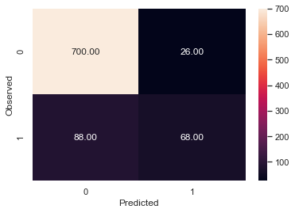

```
None

Recall: 0.4358974358974359

Precision: 0.723404255319149

F1 Score: 0.5439999999999999

Roc Auc Score: 0.7000423818605636
```

```python
# final model after improvement

model = LogisticRegression(random_state=7,penalty='l1',solver='liblinear')
model.fit(xtrain, ytrain)
y_predict = model.predict(xtest)
print("Trainig accuracy",model.score(xtrain,ytrain))
print()
print("Testing accuracy",model.score(xtest, ytest))
print()
print('Confusion Matrix')
print(draw_cm(ytest,y_predict))
print()
print("Recall:",recall_score(ytest,y_predict))
print()
print("Precision:",precision_score(ytest,y_predict))
print()
print("F1 Score:",f1_score(ytest,y_predict))
print()
print("Roc Auc Score:",roc_auc_score(ytest,y_predict))
```

```python
confusion_matrix(ytest, y_predict)
```

```
array([[700,  26],
       [ 88,  68]], dtype=int64)
```

#### Confusion Matrix (Final)

- True Positive (TP) (Observed = 1, Prodicted = 1) = 68
- False Positive (FP) (Ovserved = 0, Prodicted = 1) = 26
- True Negative (TN) (Observed = 0, Predicted = 0) = 700
- False Negative (FN) (Observed = 1, Predicted = 0) = 88

###### Step 06 ..

#### Conclusion and Business Understanding of Model

In addition to other factors that are less correlated to Attrition as illustrated in this analysis.

From a business approach, it is strongly recommended that the company will consider a Retention Plan that will have emphasis on the factors leading to Attrition, while monitoring the active employees that are highly predicted to attrite